# Assignment 4 - Iteration

Author

Mari Amirbekyan

# 1 Goal of this assignment

The goal of this assignment is for you to **apply different iteration concepts** learned in class to a new data set.

In specific, you will be asked to:  
- create a function to automate plot creation  
- apply this function to different parts of a dataset through the use of the map function.

# 2 Instructions

- Move this script into the `code` subfolder of your `04_iteration` project
- On this script, fill your name under the `title` section of the YAML
- On this script, you will be asked to:
  - Import the raw soybeans data set used in the `02_wrangling` project
  - Create a function to automate the creation of boxplots
  - Create a map workflow to apply your function to different locations in the data set

# 3 Code

Hereafter is where you will develop your code.  
Remember to load any necessary packages and the data.

**Setup**

```r
# Loading packages
library(tidyverse) # for data wrangling and plotting. Has purrr functions (the maps)
library(janitor) # clean column names
library(knitr) # for figure displaying
library(readxl) # to read excel files
library(ggplot2) #to make the boxplot
```

**Loading Data**

```r
soyk <- read_excel("../data/01_soybeans.xlsx")
view(soyk) #so I can see it in a separate tab easily
soyk #so I can see it as a tibble inline with script
```

```
# A tibble: 16 × 8
    Plot   TRT stage `K rate (lbac)` `Tifton K pct` `Midville K pct`
   <dbl> <dbl> <chr>           <dbl>          <dbl>            <dbl>
 1   105     1 R4                  0           2.63             1.17
 2   203     1 R4                  0           2.76             1.22
 3   305     1 R4                  0           2.79             1.32
 4   401     1 R4                  0           2.67             1.14
 5   102     2 R4                 50           2.48             1.6
 6   207     2 R4                 50           2.87             1.28
 7   306     2 R4                 50           3.04             1.3
 8   402     2 R4                 50           2.67             1.34
 9   106     4 R4                100           2.83             1.85
10   202     4 R4                100           3.17             1.74
11   307     4 R4                100           2.95             1.5
12   404     4 R4                100           2.79             1.19
13   103     5 R4                150           2.94             1.94
14   201     5 R4                150           2.84             1.56
15   304     5 R4                150           2.76             1.47
16   407     5 R4                150           3.01             1.51
# ℹ 2 more variables: `Watkinsville K pct` <dbl>, `Macon K pct` <dbl>
```

**Playing with the Data**

```r
#The goal will be to make a general function that shows a box plot for each K rate,
#where the plot shows distribution of measured leaf potassium levels for each
#applied concentration.

soyk_1 <- clean_names(soyk)

soyk_1
```

```
# A tibble: 16 × 8
    plot   trt stage k_rate_lbac tifton_k_pct midville_k_pct watkinsville_k_pct
   <dbl> <dbl> <chr>       <dbl>        <dbl>          <dbl>              <dbl>
 1   105     1 R4              0         2.63           1.17               3.21
 2   203     1 R4              0         2.76           1.22               2.9
 3   305     1 R4              0         2.79           1.32               3.33
 4   401     1 R4              0         2.67           1.14               3.13
 5   102     2 R4             50         2.48           1.6                3.24
 6   207     2 R4             50         2.87           1.28               3.28
 7   306     2 R4             50         3.04           1.3                3.11
 8   402     2 R4             50         2.67           1.34               3.35
 9   106     4 R4            100         2.83           1.85               3.13
10   202     4 R4            100         3.17           1.74               3.1
11   307     4 R4            100         2.95           1.5                3.16
12   404     4 R4            100         2.79           1.19               2.95
13   103     5 R4            150         2.94           1.94               3.05
14   201     5 R4            150         2.84           1.56               3.2
15   304     5 R4            150         2.76           1.47               3
16   407     5 R4            150         3.01           1.51               3.21
# ℹ 1 more variable: macon_k_pct <dbl>
```

## 3.1 Q1 - Create a function

Here, you are asked to create a function.  
The goal of this function is to create a box plot of K leaf concentration as a function of K rates.  
Name the function `myplot`.  
The function inputs are:  
- df: the data set containing the columns needed for plotting  
- x: the column name inside df to be plotted on the x axis  
- y: the column name inside df to be plotted on the y axis

Once you create the function, make sure it works by applying it to one of the locations where K leaf concentration was collected.

**Practice Making a Boxplot**

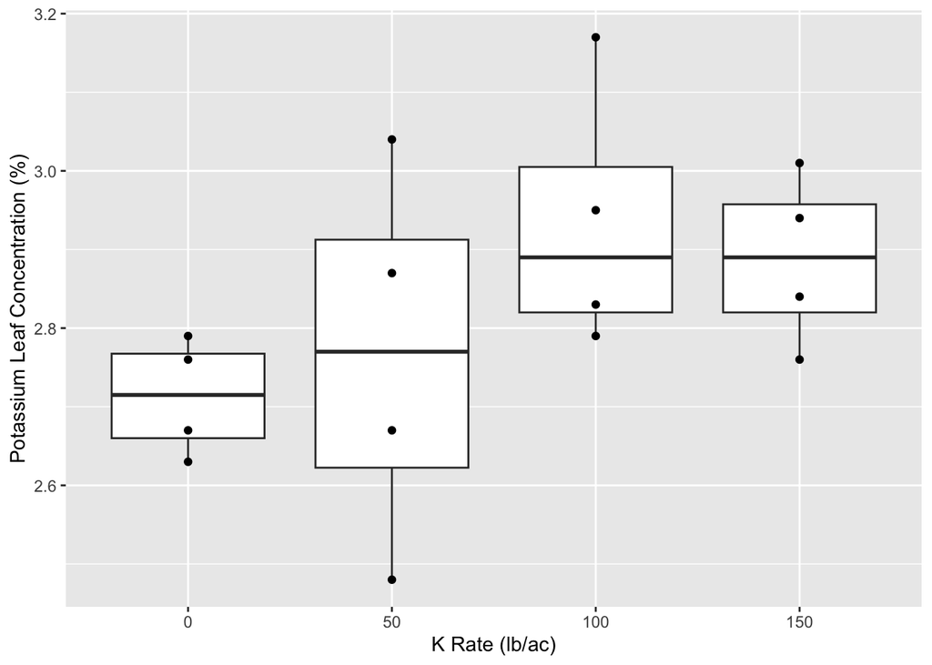

```r
#First, making a simple, direct example boxplot for a location and different k rates
#(to see what the function output should look like):
ggplot(soyk_1,
       aes(x = factor (k_rate_lbac),
           y = tifton_k_pct)) +
      geom_boxplot() +
      geom_point() +
      labs(x = "K Rate (lb/ac)",
           y = "Potassium Leaf Concentration (%)")
```

**Creating the Function and Making sure it works**

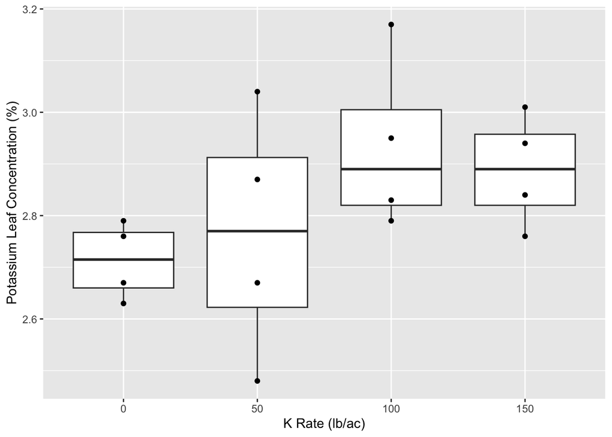

```r
myplot <- function(df, x, y) {
  ggplot(df,
       aes(x = factor({{x}}), #Double curly brackets are for the changing variable
           y = {{y}})) +
      geom_boxplot() +
      geom_point() +
      labs(x = "K Rate (lb/ac)",
           y = "Potassium Leaf Concentration (%)")
}

myplot(soyk_1, k_rate_lbac, tifton_k_pct)
```

## 3.2 Q2 - Iterate over locations

On the step above you created a function to create boxplot for one location (one column in your original data set).

Now, you are asked to apply this function to each location in the data set.  
For that, use one of the functions in the `map` family from the purr package.  
When making your plots, make sure to add a title to represent which location is represented in each plot.

**Using that Function to Iterate Over Locations**

```r
#Note: We only have a single iterating element - the location.
#So, we use the map(x) function.
#I changed it to .data[[]] because y changes, and {{}} didnt work with paste()

myplot2 <- function(df, x, y) {
  ggplot(df,
         aes(x = factor({{ x }}),
             y = .data[[y]])) +
    geom_boxplot() +
    geom_point() +
    labs(title = paste("Location:", y), #because we want it to take y's titles
         x = "K Rate (lb/ac)",
         y = "Potassium Leaf Concentration (%)")
}
```

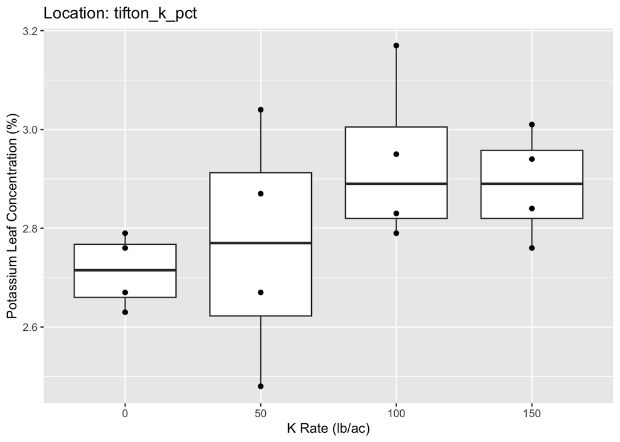

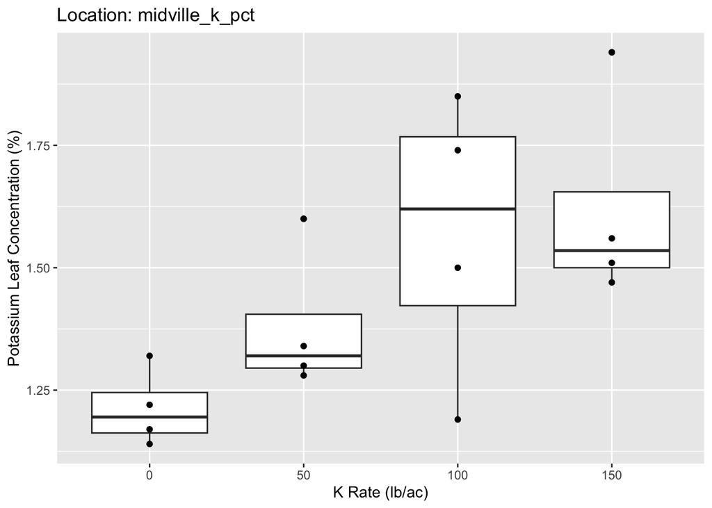

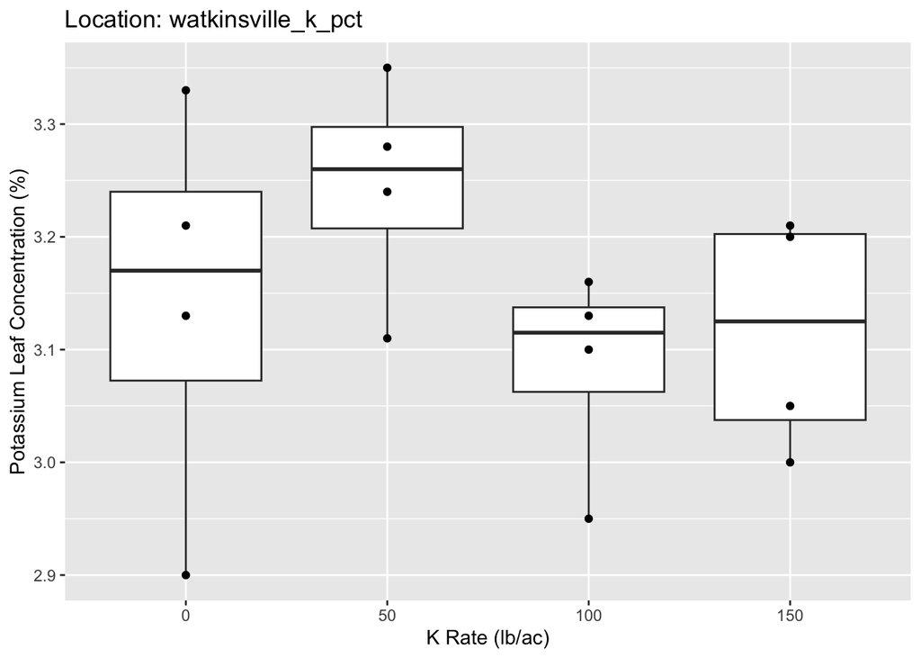

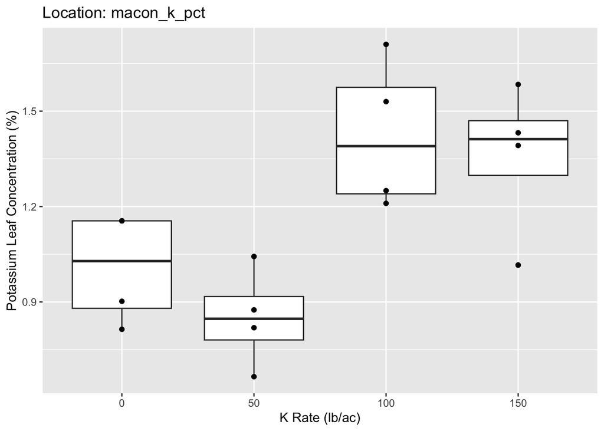

```r
locations <- soyk_1 %>%
  select(tifton_k_pct:macon_k_pct) %>%
  names()
#names(soyk_1) lists the column headers as the output of the locations object


iterated_boxplots <- map(locations, #asking it to remember the global object first
                 ~myplot2(soyk_1, k_rate_lbac, .x))

iterated_boxplots
```

Within ~myplot2(): It matches the order we made in the myplot2 function:

soyk_1 = df

k_rate_lbac = x

.x = y (the iterative component: .x is the placeholder for what map() will pick out of soyk_1 from locations and apply that to the function. If I had used pivot_longer, “locations” would just be the name of the column I’m iterating .x over.)

# 4 Submitting your work

Once you have developed all the code and answers, make sure to Render this quarto file.

**Notes on rendering**:

- Make sure to render your work and inspect how the final html looks like.
- If it does not look professional for whatever reason, then fix the issue, re-render it, recheck.
- Only send me your work once your html file looks professional.
  - **DO NOT** delete the file’s heading levels (# and ##). They set up the proper heading 1 and 2 levels, and I use them to guide my grading.
  - If a given chunk is also outputting warnings or messages, inhibit this behavior by changing the chunk options `message` and `warning` to `FALSE` (I’ll demo this in a moment).
  - If, after rendered, 2 lines of text are connected and you wish to “break line” between them, add 2 extra spaces after the first one (I’lld demo this in a moment).

After rendering, an .html file will be created on your `code` folder.

Rename this file to `Assignment-04-iteration-LASTNAME.html`.

For ex., mine would be `Assignment-04-iteration-Bastos.html`.

Submit your work by uploading the **html** file to **eLC Assignment #4 - Iteration** by Feb 16 11:59 pm.